# IODS course project

Daniel Persson

# Introduction to Open Data Science - Course Project

# About the project

```r
# This is a so-called "R chunk" where you can write R code.

date()
```

```
## [1] "Sun Dec 12 20:46:53 2021"
```

## **Initial thoughts on the course**

I look very much forward to get more knowledge with regards to the usage of programming languages and specifically R. I have in my work so far, analyzing imaging data collected with MRI, CT and SPECT, been relying on the code provided to me from our computer scientists. Hence, my experience of R and Python so far are limited to understanding what the code given me can do and sometimes being able to change a few parameters.

I am looking forward to being able to modify prior code in a more sophisticated way, and hopefully after this course be able to produce some part of the analysis parameters myself. Especially with regards to statistics and being able to supplement the nice graphs produced in R with also a numeric output, where I earlier been able to use R to draw the graphs, but been using other software for the statistical calculations.

With the aim of becoming a bit more independent in the computer analysis of my collected experimental data, I have been looking for a course like this one. Hence, I got very happy when I received an email from the internal doctoral program of drug research email list.

## link to GitHub repository

[link] (https://github.com/danieper/IODS-project)

# Regression and model validation

```r
date()
```

```
## [1] "Sun Dec 12 20:46:53 2021"
```

**To start, the working directory it assigned to where the data set is stored and the data is read from pre processed csv file. To get an initial understanding of the data set the structure and dimensions are investigated**

```r
#Setting Working Directory
setwd("C:/IODS/IODS-project")

#Reading the data set
learning2014_subset <- read.csv("data/learning2014_subset.csv")

#Investigating the structure and dimantions of the data set
str(learning2014_subset)
```

```
## 'data.frame':    166 obs. of  7 variables:
##  $ gender  : chr  "F" "M" "F" "M" ...
##  $ age     : int  53 55 49 53 49 38 50 37 37 42 ...
##  $ attitude: num  3.7 3.1 2.5 3.5 3.7 3.8 3.5 2.9 3.8 2.1 ...
##  $ deep    : num  3.58 2.92 3.5 3.5 3.67 ...
##  $ stra    : num  3.38 2.75 3.62 3.12 3.62 ...
##  $ surf    : num  2.58 3.17 2.25 2.25 2.83 ...
##  $ points  : int  25 12 24 10 22 21 21 31 24 26 ...
```

```r
dim(learning2014_subset)
```

```
## [1] 166   7
```

As we can read out from the file name “learning2014_subset”, the data set used in this chapter is a subset of “learning2014”. Learning2014 is a summary of the answers received from students in a course survey, evaluating teaching and learning, conducted between 2014.12.03 - 2015.01.10 following the completion of the course “Johdatus yhteiskuntatilastotieteeseen, syksy 2014” (in English: Introduction to Social Statistics, Autumn 2014).

The full data set can be found on: [link] (https://www.mv.helsinki.fi/home/kvehkala/JYTmooc/JYTOPKYS3-data.txt)

and a full data description can be found on: [link] (https://www.mv.helsinki.fi/home/kvehkala/JYTmooc/JYTOPKYS2-meta.txt)

The questions in the survey was designed to be answered using a 5 levels likert scale, where each question was answered by choosing a number between **1-5** representing how well the statement aligned with the students experience. The questions belonged to one of the 4 different categories listed below, (for further analysis, the abbreviation showed within parenthesis will be used):

1. The students general attitude to statistics (**attitude**).
2. The strategy the student used to study during the course (**stra**).
3. The students tendency to use a *“surface approach”* (**surf**) to get through the course material e.g. memorizing information without understanding or aiming on just passing the course.
4. The students tendency to use a *“deep approach”* (**deep**) to get through the course material e.g. intending to maximize the understanding of the provided information and strong commitment to learning.

The “learning2014_subset” data collection has been processed to enable a better overview of how the students performances, e.g. final exam results, are connected to the students attitude, study strategy and study approach, as well as, age and gender of the student.

To make the categories, including multiple question, more manageable the mean of the values scored for all questions in each of the four categories, respectively is used for the analysis. This processing step explains why a survey including only natural numbers as answers can be displayed with decimal numbers. The answers from 17 individuals has been excluded from further analyzes, due to no exam result (0 points on the exam).

**To get a better understanding of how the data look, and where to analyze further, we start with creating a overview diagram including all of the comparisons in one image. Gender define the color scheme, where red color represent female students and cyan color represent male once**

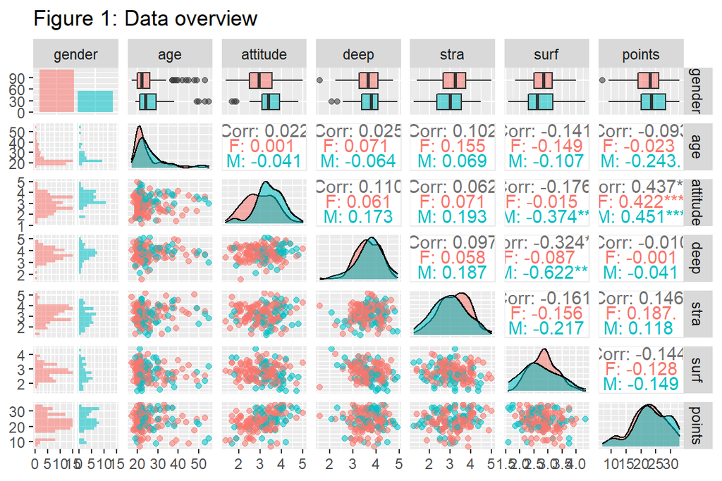

```r
#Setting Working Directory
setwd("C:/IODS/IODS-project")
#Reading the data set
learning2014_subset <- read.csv("data/learning2014_subset.csv")

library(ggplot2)
library(GGally)
p <- ggpairs(learning2014_subset, mapping = aes(col = gender, alpha = 0.5), title = "Figure 1: Data overview", lower = list(combo = wrap("facethist", bins = 15)))

p
```

As we can see in figure 1, when using the “ggpairs” function we get an initial comparison containing two outputs for each of the pairs, one in the form of graphs where the data points in plotted for each pair and one output showing a pairwise statistical comparison of the data. Since we are interested in how the variables are connected to the learning outcome among the students after the course, displayed as points, the right column and bottom row is the most interesting plots to investigate.

At a first glance the variable standing out, both while investigating the plots and the numerical values, is the correlation between attitude to statistics and points received at the final exam. Investigating the data further, there might also be a positive correlation between points received and the strategy used by the students and a negative correlation between a surface learning approach and points received. Hence, the three variables was chosen for further investigation.

**We hence, first apply a linear regression model investigating the relationship between points received on final exam and each of the three identified variables.**

```r
library(sjPlot)
library(sjmisc)
library(sjlabelled)
m <- lm(points ~ attitude + stra + surf, data = learning2014_subset)

tab_model(m, title = "Table 1", dv.labels = "First model", show.se = TRUE, show.ci = FALSE,show.stat = TRUE, show.p = TRUE, string.p = "p-value", string.stat = "t-value")
```

```
## Argument 'df_method' is deprecated. Please use 'ci_method' instead.
```

Table 1

|  | First model |  |  |  |
| --- | --- | --- | --- | --- |
| Predictors | Estimates | std. Error | t-value | p-value |
| (Intercept) | 11.02 | 3.68 | 2.99 | **0.003** |
| attitude | 3.40 | 0.57 | 5.91 | **<0.001** |
| stra | 0.85 | 0.54 | 1.58 | 0.117 |
| surf | -0.59 | 0.80 | -0.73 | 0.466 |
| Observations | 166 |  |  |  |
| R<sup>2</sup> / R<sup>2</sup> adjusted | 0.207 / 0.193 |  |  |  |

The table column reads:

- Estimates - The amount of units in points the exam results change for a change of one unit of the specific variable.
- Str. Error - The variation within the sample for the estimate.
- t-value - The fraction of the estimate divided with the standard error of the estimate
- p-value - A statistical comparison, evaluating whether the calculated estimate is different from the 0-hypothesis that a change the specific variable would have 0 affect on points received.

Reading the table 1, with this background, we find that for:

- attitude
  - The estimate of change in points depending on the attitude of the students, suggest that for each change in the unit, describing students attitude to statistics, the exam points will change in the same direction with a magnitude of ~3.40 units, with a standard error of ~0.57.
  - As we can see in the right column the statistical test suggest a significant correlation between attitude to statistics and points received on the exam.
- strategy
  - While analyzing the influence the study strategy has on on the received points, a smaller change of ~0.85 in points on the exam are estimated to be changed with one unit of strategy, with a standard error of 0,54.
  - As seen in the right column the statistical comparison suggest this change to be non significant, likely connected to the relative large error in comparison with the estimated change.
- surface learning approach
  - For the surface learning approach variable the estimate is that for each unit of change the points would change with ~0.59 units, with a standard error of ~ 0.80.
  - Considering a standard error larger than the estimate, it is not surprising that the statistical test came out suggesting a non significant comparison.

Over all the data can be interpreted as that the result on the exam is partly dependent on the attitude the student has to statistics or that the attitude to statistics after finalizing the *“Introduction to Social Statistics”* course are dependent on the performance during the course reflected in the exam points.

**Having ruled out a significant correlation between exam outcome and strategy respectively learning approach, a new second linear regression model are created to investigate the relesionchip between points and attitude alone.**

```r
#models and tabel creation
m <- lm(points ~ attitude + stra + surf, data = learning2014_subset)

m2 <- lm(points ~ attitude, data = learning2014_subset)

tab_model(m, m2, title = "Table 2", dv.labels = c("First model", "Second model"), show.se = TRUE, show.ci = FALSE,show.stat = TRUE, show.p = TRUE, string.p = "p-value",string.est = "Estimates",string.se = "std. Error", string.stat = "t-value")
```

```
## Argument 'df_method' is deprecated. Please use 'ci_method' instead.
## Argument 'df_method' is deprecated. Please use 'ci_method' instead.
```

Table 2

|  | First model |  |  |  | Second model |  |  |  |
| --- | --- | --- | --- | --- | --- | --- | --- | --- |
| Predictors | Estimates | std. Error | t-value | p-value | Estimates | std. Error | t-value | p-value |
| (Intercept) | 11.02 | 3.68 | 2.99 | **0.003** | 11.64 | 1.83 | 6.36 | **<0.001** |
| attitude | 3.40 | 0.57 | 5.91 | **<0.001** | 3.53 | 0.57 | 6.21 | **<0.001** |
| stra | 0.85 | 0.54 | 1.58 | 0.117 |  |  |  |  |
| surf | -0.59 | 0.80 | -0.73 | 0.466 |  |  |  |  |
| Observations | 166 |  |  |  | 166 |  |  |  |
| R<sup>2</sup> / R<sup>2</sup> adjusted | 0.207 / 0.193 |  |  |  | 0.191 / 0.186 |  |  |  |

**To supplement the table summary, a zoomed in version of the graphical representation in figure 1 is showed (Figure 2), as well as, a graph including the fitted linear regression model independent of gender (Figure 3)**

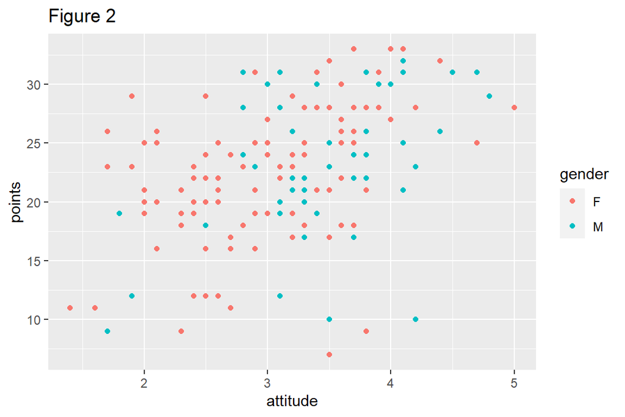

```r
#plot the comparison
library(ggplot2)

p <- ggplot(learning2014_subset, aes(x = attitude, y = points, color = gender)) +
geom_point() +
ggtitle("Figure 2")

p
```

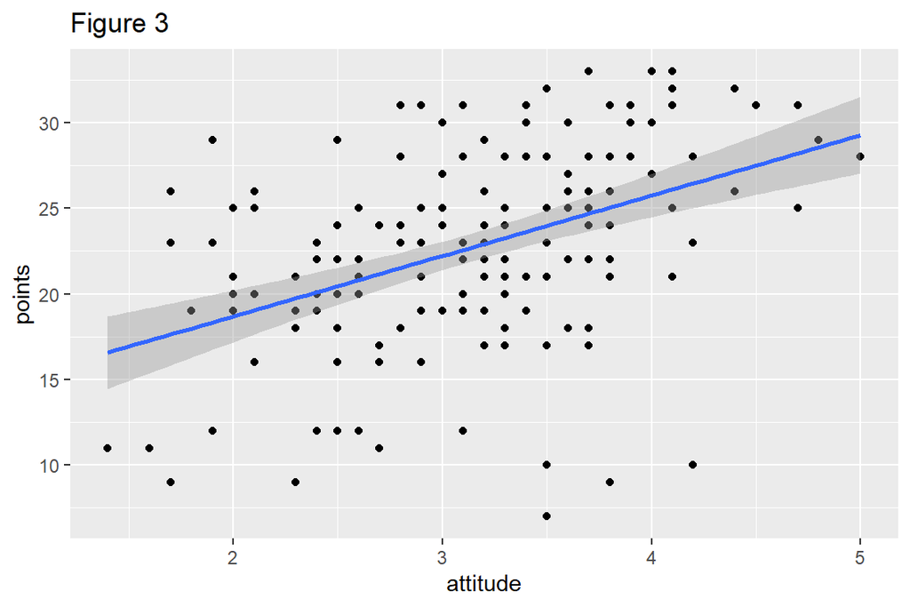

```r
p2 <- ggplot(learning2014_subset, title = "Figure 3", aes(x = attitude, y = points)) +
geom_point() +
geom_smooth(method = "lm") +
ggtitle("Figure 3")


p2
```

Table 2 displays the second model, only assessing the relationship between points and attitude, side by side with the first model. Interestingly, the estimated change in points depending on the attitude of the students are slightly higher in the second model (~3.53 compared to ~3.40 units) while the standard error is within the same magnitude of ~0.57. As we can see in the p-value columns that the statistical test still suggest a strong significant correlation between attitude to statistics and points received on the exam.

At this point, its interesting to also look at the $R^{2}$ values calculated for the model.

**Briefly:**

The $R^{2}$ is calculated by dividing the variance explain my the model (m) with the total (t) variance:

$R^{2} = Variance_m/Variance_t$

Hence, an optimal correlation would give 100%, while no correlation at all 0%.

The $R^{2}$ value for the models created in this chapter, suggest that at least 19% of the variation in the points received on the final exam, is explained by the variation in attitude to statistics.

The interpretation of $R^{2}$ values should though, in general, be done with caution since it’s not a direct measure of how well the model fit the data. One of the factors that has to be considered assessing the $R^{2}$ value, is that $R^{2}$ always increase for each additional variable included, which can partly explain why we have a lower $R^{2}$ value in the second model. The adjusted $R^{2}$ measurement is designed to take care of this problem, by adding addition parameters considering the total sample size (n) and number of independent variables (k).

$R^{2}adjusted= 1- (((n-1)*(1-R^{2}))/(n-k-1))$

e.g., for the second model:

$R^{2}adjusted_M1= 1- (((166-1)*(1-0.191))/(166-1-1))=0,186$

Unfortunately this adjustment don’t take care of all issue in interpreting the $R^{2}$ measurements. For example the $R^{2}$ values could be rather large even with a model not fitting the data if it happens that the model, intersects the real data at multiple time points.

For this reason we need to also validate the assumptions done creating the models, by producing residual plots. The residual plots are used to investigate if our model following the assumptions on which it rely:

- The assumption that the errors are normally distributed (Normal Q-Q plot),
- The assumption that the errors have constant variance (Residuals vs. Fitted plot)
- The assumption that not a single or multiple outliers skew the plot fit (Residuals vs. Leverage)

**The produced residual plots are displayed in figure 4 and discussed below**

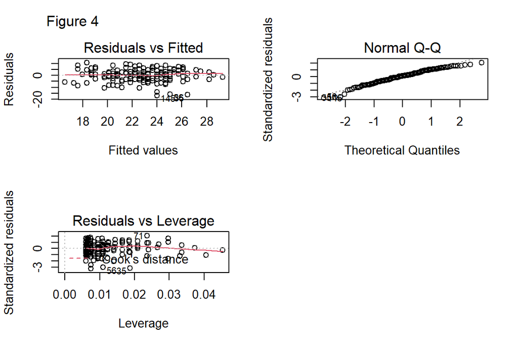

```r
par(mfrow = c(2,2))
plot(m2, which = c(2,1,5))
mtext("Figure 4", side = 3, line = -2, adj =0.1, outer = TRUE)
```

- That there is no obvious pattern in the “residual vs. Fitted” panel, suggesting that the error in the model have a rather constant variance.
- That according to the Q-Q plot the errors seem to be normal distributed.
- Analyzing the “Residuals vs. Leverage” plot that even though a few outliers exist in the “Residuals vs. Fitted” plot, since these are located in the middle of the data set, no data point is having any large impact on the model fit.

## summary

**In this chapter we are using a linear regression model to investigating the relationship between points received on the final exam on the course “Introduction to Social Statistics”in Autumn 2014, and the attitude to statistics, study strategy, and study approach respectively. We identified that attitude to statistics correlated with the points received on the exam with an estimate that at least 19% of the variance in points was connected to attitude. The model assumptions was validated utilizing multiple residual plots. Overall we can state that the result on the exam is partly dependent on the attitude the student has to statistics or that the attitude to statistics after finalizing the *“Introduction to Social Statistics”* course are dependent on the performance during the course reflected in the exam points.**

# Logistic regression

```r
date()
```

```
## [1] "Sun Dec 12 20:47:03 2021"
```

```r
#Setting Working Directory
setwd("C:/IODS/IODS-project")

#loading the data
alc <- read.table("data/alc.csv", sep = ",", header=TRUE, stringsAsFactors = TRUE)

variable.names(alc)
```

```
##  [1] "school"     "sex"        "age"        "address"    "famsize"
##  [6] "Pstatus"    "Medu"       "Fedu"       "Mjob"       "Fjob"
## [11] "reason"     "guardian"   "traveltime" "studytime"  "schoolsup"
## [16] "famsup"     "activities" "nursery"    "higher"     "internet"
## [21] "romantic"   "famrel"     "freetime"   "goout"      "Dalc"
## [26] "Walc"       "health"     "n"          "id.p"       "id.m"
## [31] "failures"   "paid"       "absences"   "G1"         "G2"
## [36] "G3"         "failures.p" "paid.p"     "absences.p" "G1.p"
## [41] "G2.p"       "G3.p"       "failures.m" "paid.m"     "absences.m"
## [46] "G1.m"       "G2.m"       "G3.m"       "alc_use"    "high_use"
## [51] "cid"
```

The data set described and studied in this chapter is a combination of two studies investigating how demographic, social and school related factors affect the students achievement in secondary education of two Portuguese schools. The performance is investigated in two subjects, mathematics (.m) and Portuguese language (.p) for three different time points G1(first), G2(second) and G3(final).

The purpose of the analysis performed in this chapter is to use the information in the data set to assess how alcohol consumption influence the result of students and study factors that in turn affect the alcohol consumption, to enable directed measures.

Since alcohol consumption in the world, in general, varies between male and female in that men both drink more often and have a higher tendency to binge drink than woman, we hypothesis that this will be the case also in the current data set and for all graphical comparison a distinguishing will be performed between male and female using color.

The hypothesis is that a high alcohol consumption would result in a higher risk of the student being absent from and failing to pass the classes, since alcohol consumption impair the brains working capacity and body functioning in multiple ways, e.g., damaging the sleep pattern, decreased memory capacity and increased risk for illness. with the same background, the hypothesis would be that even if the student are not failing the class the final grade would be affected.

**To give more meaning to the graphs investigating the variables and alcohol consumption lets first look at the within variable distribution of sex and alcohol consumption**

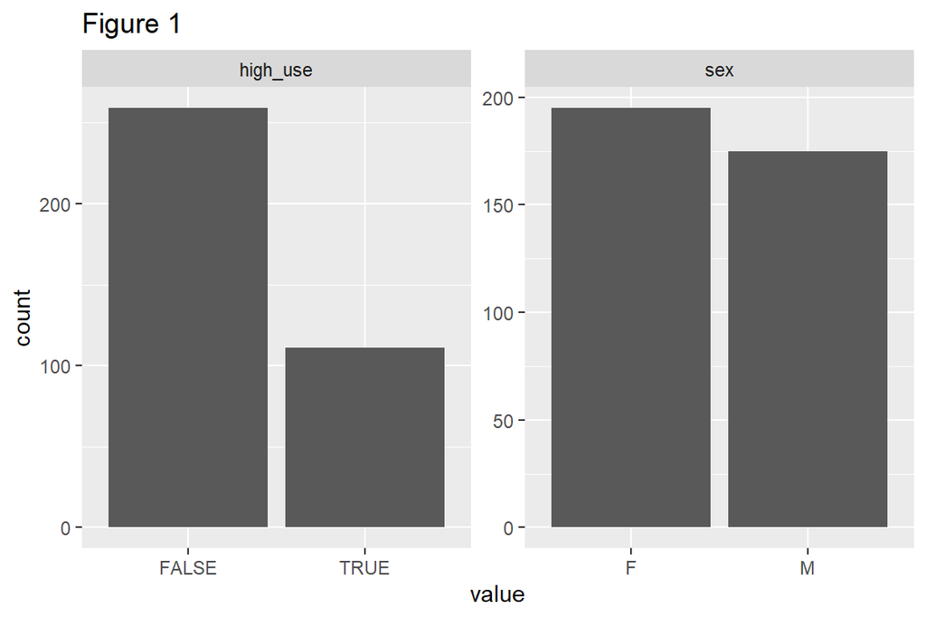

```r
# access the tidyverse libraries tidyr, dplyr, ggplot2
library(tidyr); library(dplyr); library(ggplot2); library(cowplot)
alc_interest <- select(alc, one_of("high_use", "sex"))

gather(alc_interest) %>% ggplot(aes(value)) + facet_wrap("key", scales = "free") +
geom_bar() +
ggtitle("Figure 1")
```

```r
summary(alc$sex)
```

```
##   F   M
## 195 175
```

```r
summary(alc$high_use)
```

```
##    Mode   FALSE    TRUE
## logical     259     111
```

As we can read from figure 1 and associated summery tabels:

- There is almost as many men and woman in the data set, with only a slightly higher portion of female students.

  and
- About $2/7$ of the students have a high use of alcohol.

**To then asses the relationship between the variables and high alcohol a second set of graphs is produced**

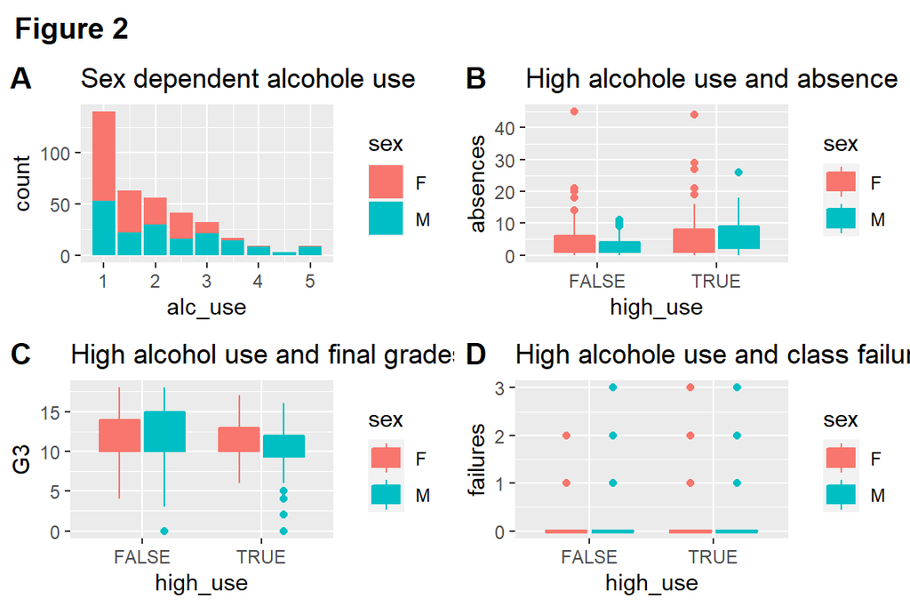

```r
p1 <- ggplot(data = alc, aes(x = alc_use, fill = sex)) +
geom_bar() +
ggtitle("Sex dependent alcohole use")

p2 <- ggplot(data = alc, aes(x = high_use, y = failures, fill = sex, color = sex)) +
geom_boxplot() +
ggtitle("High alcohole use and class failure")

p3 <- ggplot(data = alc, aes(x = high_use, y = absences, fill = sex, color = sex)) +
geom_boxplot() +
ggtitle("High alcohole use and absence")

p4 <- ggplot(data = alc, aes(x = high_use, y = G3, fill = sex, color = sex)) +
geom_boxplot() +
ggtitle("High alcohol use and final grades")

p <- plot_grid(p1, p3, p4, p2, labels = c('A', 'B', 'C', 'D'))

title <- ggdraw() +
draw_label( "Figure 2",
    fontface = 'bold', x = 0, hjust = 0 ) +
  theme(
    # add margin on the left of the drawing canvas,
    # so title is aligned with left edge of first plot
    plot.margin = margin(0, 0, 0, 7))
plot_grid( title, p, ncol = 1,
  # rel_heights values control vertical title margins
  rel_heights = c(0.1, 1))
```

```r
summary(alc$absences)
```

```
##    Min. 1st Qu.  Median    Mean 3rd Qu.    Max.
##   0.000   1.000   3.000   4.511   6.000  45.000
```

```r
summary(alc$failures)
```

```
##    Min. 1st Qu.  Median    Mean 3rd Qu.    Max.
##  0.0000  0.0000  0.0000  0.1892  0.0000  3.0000
```

```r
summary(alc$G3)
```

```
##    Min. 1st Qu.  Median    Mean 3rd Qu.    Max.
##    0.00   10.00   12.00   11.52   14.00   18.00
```

Figure 2 shows an overview of the four factors described in relation to alcohol consumption, the summary of the within variable distribution not previously described is showed in associated tables. High consumption has been defined as an average grading of workday and weekend alcohol consumption as 3-5 on a likert scale ranging from 1 (very low) to 5 (very high), the full distribution is showed in panel A. As we can see in panel A, the hypothesis that the male students would drink more alcohol than female seem to be correct and hence our population is also representative for the society in general.

The initial graphs showed in panel B and C also suggest that the hypothesis that high alcohol consumption would result in higher absence and lower final grades could be true.

In contrast panel D suggest that the alcohol consumption would not affect the number of students failing in the passing the class to much. However the reader should notice that in our data sett the amount of student falling to pass classes is very few in general and an affect could be more prominent with a larger population.

Let us anyway keep the failing variable hypothesis and see how it is handled in a logic regression model, assessing the affect of high alcohol use on the four variables with high use as a binomial factor.

**A logic regression model is produced with the variables and odds ratio and confidence intervals are calculated to investigate the statistical relationship**

```r
# find the model with glm()
m <- glm(high_use ~ failures + absences + sex + G3, data = alc, family = "binomial")

# print out a summary of the model
summary(m)
```

```
##
## Call:
## glm(formula = high_use ~ failures + absences + sex + G3, family = "binomial",
##     data = alc)
##
## Deviance Residuals:
##     Min       1Q   Median       3Q      Max
## -2.1561  -0.8429  -0.5872   1.0033   2.1393
##
## Coefficients:
##             Estimate Std. Error z value Pr(>|z|)
## (Intercept) -1.38733    0.51617  -2.688  0.00719 **
## failures     0.50382    0.22018   2.288  0.02213 *
## absences     0.09058    0.02322   3.901 9.56e-05 ***
## sexM         1.00870    0.24798   4.068 4.75e-05 ***
## G3          -0.04671    0.03948  -1.183  0.23671
## ---
## Signif. codes:  0 '***' 0.001 '**' 0.01 '*' 0.05 '.' 0.1 ' ' 1
##
## (Dispersion parameter for binomial family taken to be 1)
##
##     Null deviance: 452.04  on 369  degrees of freedom
## Residual deviance: 405.59  on 365  degrees of freedom
## AIC: 415.59
##
## Number of Fisher Scoring iterations: 4
```

```r
# print out the coefficients of the model
coef(m)
```

```
## (Intercept)    failures    absences        sexM          G3
## -1.38732604  0.50382370  0.09057516  1.00870144 -0.04670941
```

```r
# compute odds ratios (OR)
OR <- coef(m) %>% exp

# compute confidence intervals (CI)
CI <- confint(m) %>% exp
# print out the odds ratios with their confidence intervals
cbind(OR, CI)
```

```
##                    OR      2.5 %    97.5 %
## (Intercept) 0.2497422 0.08880747 0.6760545
## failures    1.6550376 1.08094265 2.5808643
## absences    1.0948038 1.04844539 1.1486025
## sexM        2.7420380 1.69666006 4.4943946
## G3          0.9543647 0.88291082 1.0311936
```

As we can see from the initial regression model alcohol use is significantly related to the sex of the student, where significantly more male student have reported high alcohol consumption. The hypothesis that high alcohol use would result in more absence are also supported by the regression model. However, while a slight affect of alcohol consumption on final grade was suggested by the graph, the model didn’t find any significant affect and in contrast the model propose that there is a slight significant relationship between alcohol use and failure of class.

The information showed by the odds ratio (OR) and confidence interval (CI) is also in line with the information found in the model summary, with rather high ORs for sex and failure, an OR a bit away from 1 for absence, but also an OR very close to 1 for final grades. For the three significant variabels the CIs are also positive for both percentiles, while for grades the CI is on oposite sides of 1 and rather tight.

Since the final grade (G3) is non significant in the first regression model, a second model with only three variables are created before used for prediction.

**A second model are created and the predicted power is calculated using the second model**

```r
# fit the model
m2 <- glm(high_use ~ failures + absences + sex, data = alc, family = "binomial")

# predict() the probability of high_use
probabilities <- predict(m2, type = "response")

# add the predicted probabilities to 'alc'
alc <- mutate(alc, probability = probabilities)

# use the probabilities to make a prediction of high_use
alc <- mutate(alc, prediction = probability > 0.5)

# see the last ten original classes, predicted probabilities, and class predictions
select(alc, failures, absences, sex, high_use, probability, prediction) %>% tail(10)
```

```
##     failures absences sex high_use probability prediction
## 361        1        7   M     TRUE   0.5745818       TRUE
## 362        0        3   M     TRUE   0.3392074      FALSE
## 363        0        2   M     TRUE   0.3188026      FALSE
## 364        0        4   M     TRUE   0.3602274      FALSE
## 365        0        3   M    FALSE   0.3392074      FALSE
## 366        0        4   M     TRUE   0.3602274      FALSE
## 367        0        0   M    FALSE   0.2800562      FALSE
## 368        1        4   M     TRUE   0.5058037       TRUE
## 369        2        8   M     TRUE   0.7292092       TRUE
## 370        1        0   M    FALSE   0.4142096      FALSE
```

```r
# tabulate the target variable versus the predictions
table(high_use = alc$high_use, prediction = alc$prediction)
```

```
##         prediction
## high_use FALSE TRUE
##    FALSE   252    7
##    TRUE     78   33
```

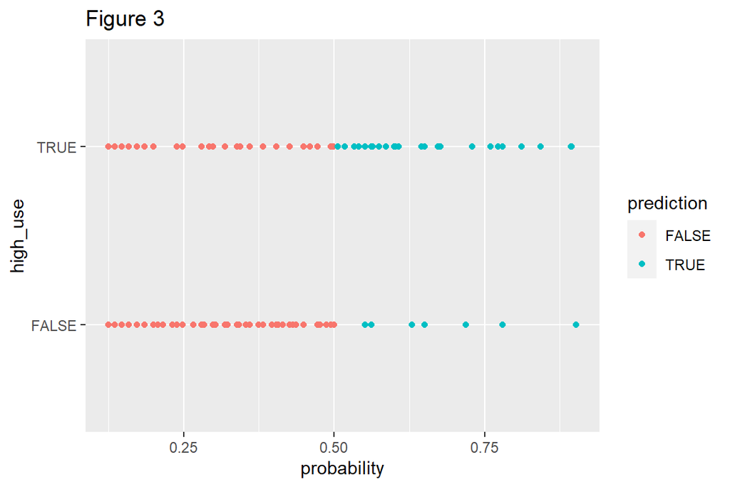

```r
# initialize a plot of 'high_use' versus 'probability' in 'alc'
g <- ggplot(alc, aes(x = probability, y = high_use, col = prediction)) +
  geom_point() +
  ggtitle("Figure 3")
g
```

```r
# tabulate the target variable versus the predictions
table(high_use = alc$high_use, prediction = alc$prediction) %>% prop.table %>% addmargins
```

```
##         prediction
## high_use      FALSE       TRUE        Sum
##    FALSE 0.68108108 0.01891892 0.70000000
##    TRUE  0.21081081 0.08918919 0.30000000
##    Sum   0.89189189 0.10810811 1.00000000
```

```r
# define a loss function (average prediction error)
loss_func <- function(class, prob) {
  n_wrong <- abs(class - prob) > 0.5
  mean(n_wrong)
}

# compute the average number of wrong predictions in the (training) data
loss_func(class = alc$high_use, prob = alc$probability)
```

```
## [1] 0.2297297
```

Average number of wrong predictions with the second model is ~0.2

**A 10 - cross validation is performed for the model**

```r
# K-fold cross-validation
library(boot)
cv <- cv.glm(data = alc, cost = loss_func, glmfit = m, K = 10)

# average number of wrong predictions in the cross validation
cv$delta[1]
```

```
## [1] 0.2486486
```

With 10 fold cross validation, the average number of wrong predictions is ~0.24 - 0.26, wish is similar or slightly lower than the one in the Data Camp exercise. No specific number can be mention since slightly different value is computed each time.